# Convênios X Fornecedores

#### Objetivo:

**identificar cidades que apresentam maiores diferenças de valores ditribuídos entre convênnios e fornecedores.**

#### Como?

**Utilizamos a função gini. O valor gini aumenta de acordo com a distribuição de valores. Quanto mais igualitária a distribuição, mais baixo será o valor gini.**

**Exemplo:**

O valor 100 está concentrado em 50% das partes no primeiro grupo e em 25% das partes no segundo grupo. Logo, o valor gini será maior no segundo grupo, já que uma pequena parte do grupo concentra um valor muito diferente das outras partes. Quanto menor uma parte representar de um todo e quanto maior e destoante o valor armazenado por essa pequena parte, maior será o gini.

```r
gini(c(100, 1))
```

```
## [1] 0.490099
```

```r
gini(c(100, 1, 1, 1))
```

```
## [1] 0.7208738
```

Note que o valor gini não se cresce muito se apenas um valor aumentar, mas a parte que ele representa permenecer a mesma.

```r
gini(c(1000, 1))
```

```
## [1] 0.499001
```

#### Os dados

Calculamos dois valores ginis para cada cidade a partir de duas variáveis diferentes. Uma é o valor que um convênio recebe de uma cidade e outra de o valor que um fornecedor recebe de uma cidade. Assim como no exemplo acima, com esses dois valores podemos ver, para cada cidade, como se comporta a distribuição de verba para convênios e fornecedores.

Tendo esses dois valores, para cada cidade, calculamos um coeficiente que se dá pela seguinte função:

`coef = gini_forncedor/gini_convenio`

Se esse coeficiente atinge altos valores, possivelmente há uma diferença significante ao comparar a ditribuição de verba entre forncecedores e entre convênios, sendo a distribuição entre fornecedores muito mais desigual e concentrada.

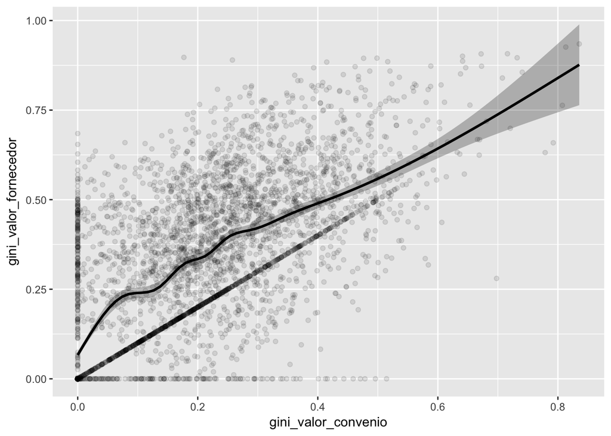

```r
ggplot(ginicities, aes(gini_valor_convenio, gini_valor_fornecedor)) + geom_point(alpha=0.1) +
    geom_smooth(alpha=0.25, color="black", fill="black")
```

Selecinamos então as 3 primeiras cidades com maiores coeficientes para tentar entender por que apresentam esses valores.

```r
ginicities[with(ginicities, order(-coef))[1:5], ]
```

```
##                        cidade gini_valor_convenio gini_valor_fornecedor
## 3840                 SOBRALIA        0.0009128667             0.3230326
## 1627                 IBICOARA        0.0018549732             0.3681131
## 2452 MORRO DO CHAPEU DO PIAUI        0.0027392209             0.4482516
## 2939                 PIRAJUBA        0.0041694752             0.5581135
## 3875               TAGUATINGA        0.0036283604             0.4722912
##          coef
## 3840 353.8662
## 1627 198.4466
## 2452 163.6420
## 2939 133.8570
## 3875 130.1666
```

### Sobralia

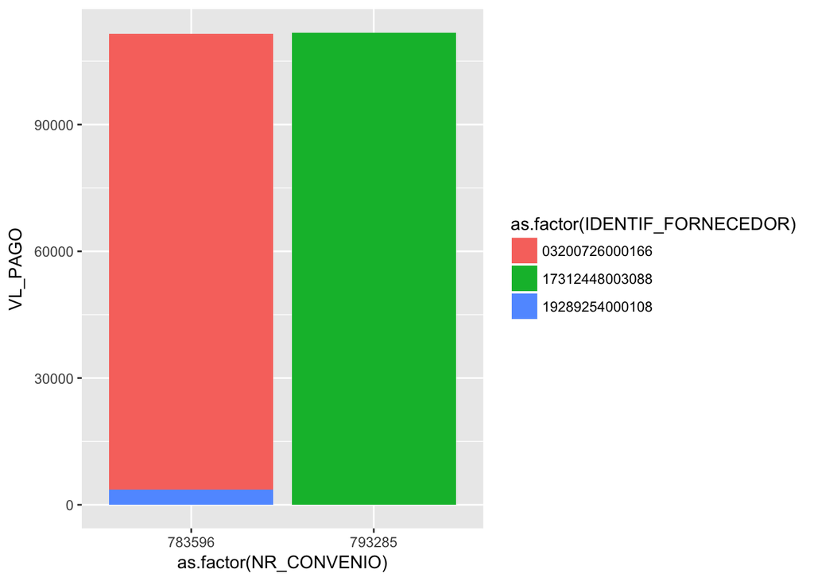

```r
ggplot(subset(pagamentos_siconv, MUNIC_PROPONENTE == "SOBRALIA"), aes(y=VL_PAGO, x=as.factor(NR_CONVENIO), fill = as.factor(IDENTIF_FORNECEDOR))) + geom_bar(stat="identity")
```

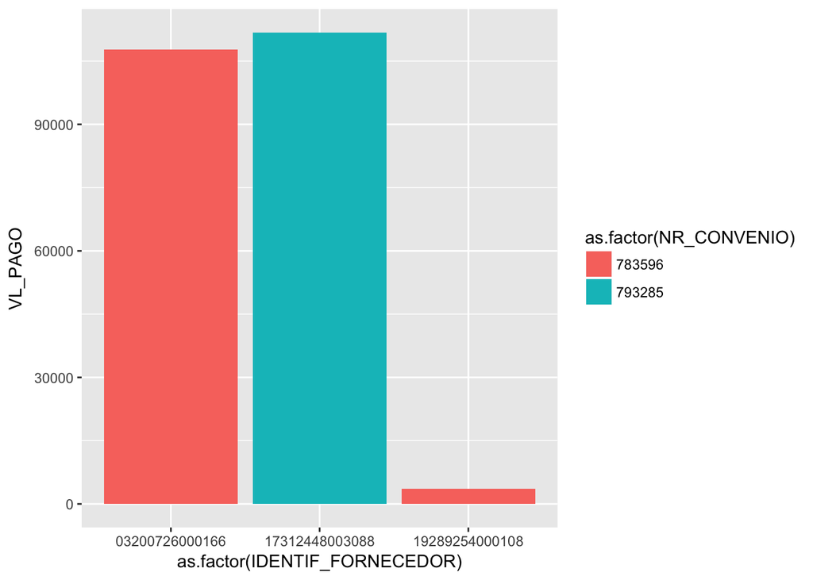

```r
ggplot(subset(pagamentos_siconv, MUNIC_PROPONENTE == "SOBRALIA"), aes(y=VL_PAGO, x=as.factor(IDENTIF_FORNECEDOR), fill = as.factor(NR_CONVENIO))) + geom_bar(stat="identity")
```

### Ibicoara

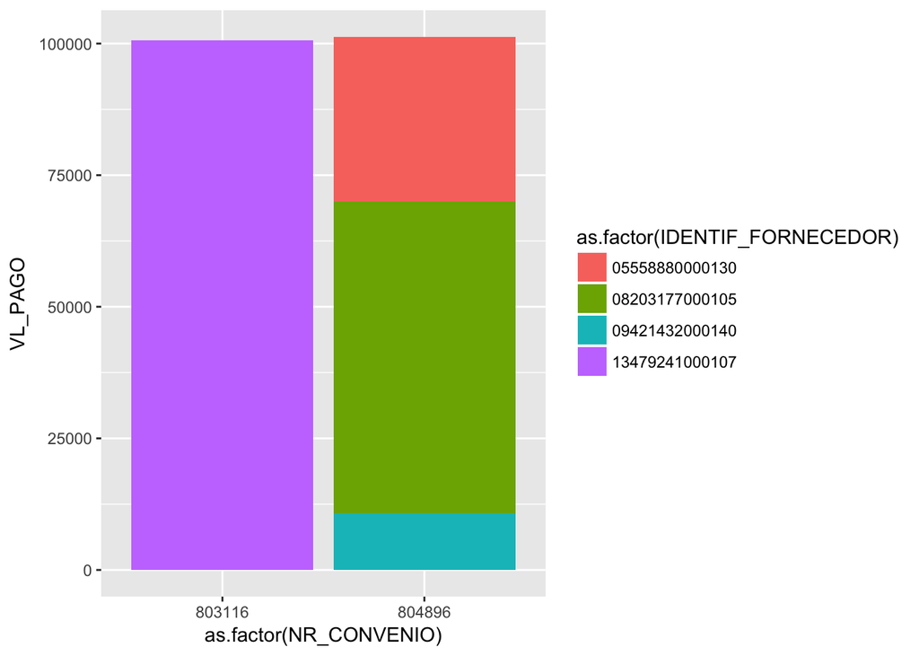

```r
ggplot(subset(pagamentos_siconv, MUNIC_PROPONENTE == "IBICOARA"), aes(y=VL_PAGO, x=as.factor(NR_CONVENIO), fill = as.factor(IDENTIF_FORNECEDOR))) + geom_bar(stat="identity")
```

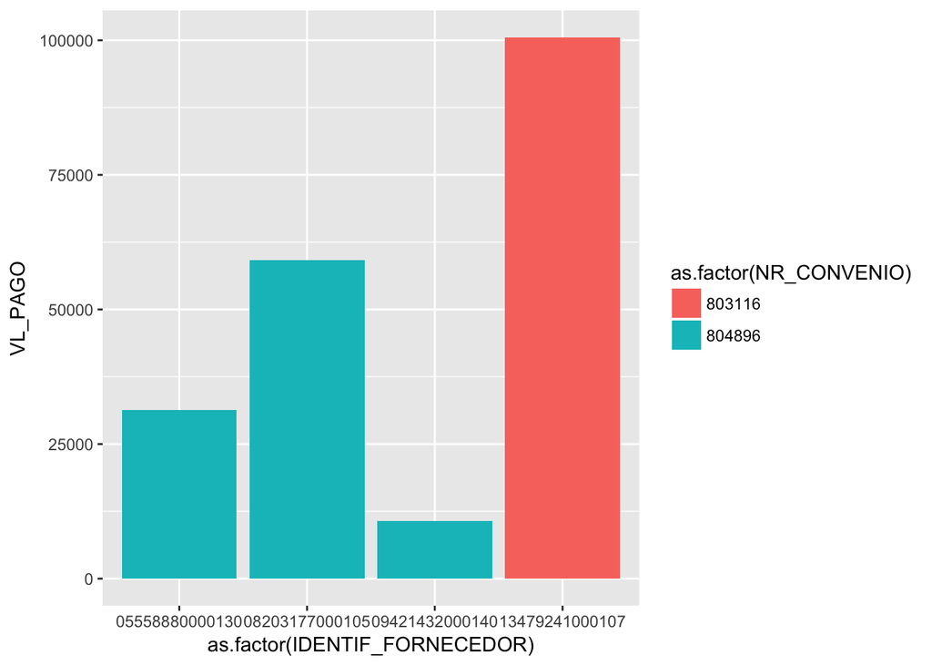

```r
ggplot(subset(pagamentos_siconv, MUNIC_PROPONENTE == "IBICOARA"), aes(y=VL_PAGO, x=as.factor(IDENTIF_FORNECEDOR), fill = as.factor(NR_CONVENIO))) + geom_bar(stat="identity")
```

### Morro dp Chapeu do Piaui

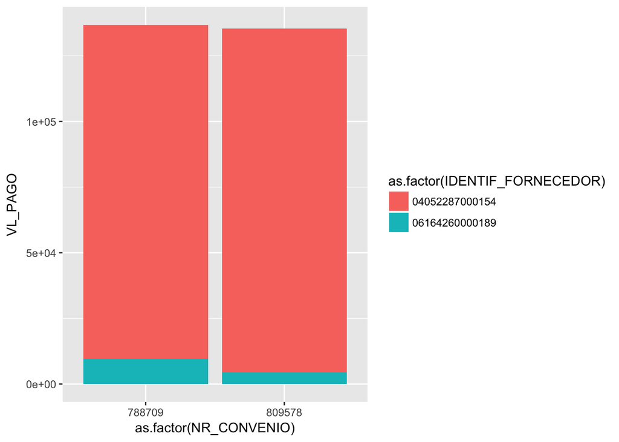

```r
ggplot(subset(pagamentos_siconv, MUNIC_PROPONENTE == "MORRO DO CHAPEU DO PIAUI"), aes(y=VL_PAGO, x=as.factor(NR_CONVENIO), fill = as.factor(IDENTIF_FORNECEDOR))) + geom_bar(stat="identity")
```

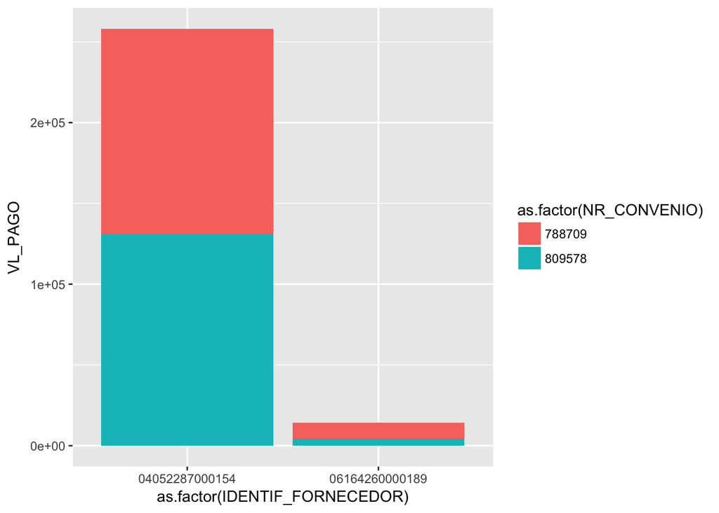

```r
ggplot(subset(pagamentos_siconv, MUNIC_PROPONENTE == "MORRO DO CHAPEU DO PIAUI"), aes(y=VL_PAGO, x=as.factor(IDENTIF_FORNECEDOR), fill = as.factor(NR_CONVENIO))) + geom_bar(stat="identity")
```